# Analyzing Customer Sentiments and Forecasting Trends at Disneyland

Zhiqing Wang, Xinyi Zhang, Ruochen Hu, Shuwen Liu, Xiaozhu Yang

2024-04-23

# **Part 1: Research Proposal**

## 1.Description of the Research Problem

Disneyland is loved by families and people of all ages. Since its beginnings, Disneyland has become more than just a regular amusement park. It’s grown into something much bigger, a symbol of dreams coming true. With its famous Sleeping Beauty Castle and exciting rides like Space Mountain, Disneyland attracts millions of visitors every year. It’s like a magical place that attracts visitors from all over the world. With its enchanting atmosphere, it invites people to explore its different areas. But there’s more to Disneyland than just fun rides and attractions. We want to understand what people think about their experience there and how we can make it even better for everyone. We discovered a dataset containing reviews of Disneyland in California, Hong Kong, and Paris. Through meticulous analysis and exploration, our research aims to provide actionable insights that enable Disneyland management to enhance services, tailor experiences, and foster lasting connections with visitors, ultimately elevating the magic of the Disneyland experience worldwide.

## 2.Literature Review

In the tourism industry, understanding customer experience is crucial, as evidenced by numerous scholarly inquiries into tourists’ experiences across diverse settings (Loureiro, 2014; Hwang & Lyu, 2015; Radder & Han, 2015). Theme parks and tourist attractions have experienced a consistent rise in attendance over the years (Milman, 2001), leading to a growing interest in assessing customer satisfaction and service quality within these destinations (Tsang et al., 2012; Bigné et al., 2005). Our research specifically focuses on exploring customers’ satisfaction and experiences at Disneyland. By delving into the intricacies of guest experiences and perceptions, we aim to identify areas for improvement to enhance overall satisfaction and loyalty. This endeavor is aligned with the broader goal of ensuring that Disneyland remains a premier destination, providing visitors with unforgettable experiences that leave a lasting impression and inspire return visits.

## 3.Research Questions

Based on our discussion of the research backgrounds and topics, our research aims to find an optimization solution for Disneyland, improving services and customers’ experiences. Therefore, the specific research questions are as follows:

1. Do customers hold positive or negative reviews in general?
2. What are the most frequent sentiments that customers’ reviews present?
3. What are the reasons for customers who leave the most negative reviews?
4. Did ratings of Disneyland differ from Hong Kong, California, and Paris?
5. Are there variations in customer ratings across different months, suggesting the existence of a seasonal pattern?
6. Do monthly visitor numbers vary between months indicating a cyclical trend?

## 4.Data Description

The datasets contain reviews and ratings of 3 Disneyland branches - California, Hong Kong, and Paris. In total, there are 42,656 observations of 6 variables. The 6 columns in the dataset collected by Disneyland are Review_ID, Rating, Year_Month, Reviewer_Location, Review_Text, Disneyland_Branch. More specific descriptions of the data are as follows:

Review_ID: unique id given to each review, a serial number column.

Rating: ranging from 1 (unsatisfied) to 5 (satisfied), numeric variable.

Year_Month: when the reviewer visited the theme park, time variable.

Reviewer_Location: country of origin of visitor, character variable.

Review_Text: comments made by visitor, character variable.

Disneyland_Branch: location of Disneyland Park, character variable.

There are multiple NAs values that were imputed with the word “Missing” in the Year_month column by the dataset collector. More specifically, there are 2613 rows containing missing values in the Year_month column, out of 42656 rows in total.

# **Part 2: Analysis Methodology**

## 1.Implementing Data Cleaning

To start with the project, we cleaned the datasets by identifying NAs and missing values. We used the function below to extract column name of numeric variables with NAs, and we found that there were no NAs in the dataset:

```r
data = read.csv("C:/Users/katew/Downloads/DisneylandReviews.csv")

# Function to get names of numeric columns with NAs
get_na_numeric_column_names <- function(df) {
  # Identifying numeric columns with NAs
  na_columns <- sapply(df, function(x) {
    if(is.numeric(x)) {
      return(any(is.na(x)))
    } else {
      return(FALSE)
    }
  })
  # Returning names of columns that are TRUE for having NAs
  names(na_columns[na_columns])
}

# Getting the list for NA’s in dataset
na_columns_data <- get_na_numeric_column_names(data)
na_columns_data
```

```
## character(0)
```

We checked if there were missing values or imputed NAs as the word ‘missing’ in the character column. We used grepl function to find rows where the Year_Month column contained the word “missing” (case insensitive):

```r
#Checking imputed NA as word 'missing' in the character column or not
is_missing <- grepl("missing", data$Year_Month, ignore.case = TRUE)
rows_with_missing <- data[is_missing, ] #Year_Month NA rows

is_missing2 <- grepl("missing", data$Branch, ignore.case = TRUE)
data[is_missing2,]
```

```
## [1] Review_ID         Rating            Year_Month        Reviewer_Location
## [5] Review_Text       Branch
## <0 rows> (or 0-length row.names)
```

```r
library(stringi)
is_missing3 <- stri_detect_fixed(data$Reviewer_Location, "missing", case_insensitive = TRUE)
data[is_missing3,]
```

```
## [1] Review_ID         Rating            Year_Month        Reviewer_Location
## [5] Review_Text       Branch
## <0 rows> (or 0-length row.names)
```

```r
#check the missing for different branch
rows_with_missing$City <- sub("Disneyland_", "", rows_with_missing$Branch)
library(dplyr)
rows_with_missing %>%
  group_by(City)%>%
  summarise(count = n())
```

```
## # A tibble: 3 × 2
##   City       count
##   <chr>      <int>
## 1 California  1204
## 2 HongKong     473
## 3 Paris        936
```

We also separated year data and month data from the Year_month column, storing Year and Month data into two new columns. We then imputed value 99 to NAs in the Year column and the Month column, instead of showing NA. Then we dropped the original Year_Month column:

```r
# Extract year and month (has NA:'missing'in Year_Month column,keep first)
data$Year <- as.numeric(sub("-.*", "", data$Year_Month))
data$Month <- as.numeric(sub(".*-", "", data$Year_Month))

#Impute 'Year' and 'Month' column's NA with 99 and drop original Year_Month column
library(dplyr)
data <- data %>%
  mutate(Year = ifelse(is.na(Year), 99, Year),
         Month = ifelse(is.na(Month), 99, Month)) %>%
  select(-Year_Month)
```

In the Branch column, we extracted city names into a new column City and dropped the original Branch column for further analysis:

```r
#Branch made of:HongKong,California,Paris;keep city name only and create new Column:city
data$City <- sub("Disneyland_", "", data$Branch)

#Drop original Branch column
library(dplyr)
data <- select(data, -Branch)
```

## 2.Choosing Analysis Methods

### 2.1 Recommender Systems

Recommender systems are typically used to predict user preferences or ratings for items based on past behavior or explicit feedback. However, our dataset contains reviews with ratings provided by users, but it also includes character variables such as Reviewer_Location and Review_Text. Recommender systems usually work with numeric data representing user-item interactions, and they might not handle character variables directly. Additionally, recommender systems are more commonly used in contexts like recommending movies, products, or articles, where the goal is to personalize recommendations for users based on their preferences so we are not going to use it in our project.

```r
#library(recommenderlab)
#data_matrix = as(data,class = 'realRatingMatrix')
```

### 2.2 Association Analysis

Association analysis, commonly used in market basket analysis, aims to identify relationships between items that co-occur frequently in transactions. However, our dataset doesn’t seem to represent transactional data where items are bought together. While it is possible to apply association analysis to other types of data, such as sequences of events or patterns in user behavior, it might not be the most suitable approach for analyzing reviews of Disneyland parks.

```r
#library(arules); library(arulesViz)
#items = read.transactions(data, format = 'basket', sep=',',skip=1)
```

### 2.3 Text Mining

Text mining is a suitable approach for analyzing reviews of Disneyland parks, offering insights into visitor sentiments and preferences. Through techniques like sentiment analysis and topic modeling, it uncovers common themes, sentiments, and patterns in the reviews. By identifying frequently mentioned topics and sentiment polarity, it reveals visitor satisfaction levels and areas for improvement. Text mining also enables comparative analysis across different dimensions, such as branches or visitor demographics. Ultimately, it generates actionable insights for enhancing visitor experiences and addressing concerns. With its ability to extract valuable information from unstructured text, text mining proves invaluable for understanding and improving the Disneyland visitor experience.

### 2.4 Time Series Analysis

Using time series analysis is beneficial for understanding how ratings and timing impact customers’ behavior. Firstly, time series techniques allow us to uncover patterns and trends in customer ratings over time, enabling us to identify any recurring patterns or seasonal variations. By examining the temporal relationship between ratings and timing variables, such as the year or month of the visit, we can assess whether certain periods exhibit higher or lower customer satisfaction levels. Additionally, time series models provide a framework for forecasting future ratings based on historical data, allowing us to anticipate potential fluctuations in customer satisfaction and plan accordingly. And thus, using time series method could help us make informed decisions to enhance customer experience and optimize business strategies at Disneyland branches.

# **Part 3. Text mining and Sentiment Analysis**

### 3.1 Calculating Mean and Median Ratings Across Different Disneyland Park Locations

We examines the ratings of reviews across different Disneyland park locations, focusing on mean and median ratings as well as the distribution of ratings for each city.

```r
data = read.csv("C:/Users/katew/Downloads/cleandata.csv")
#Mean rating review:HongKong,California and Paris
library(dplyr)
data %>%
  group_by(City) %>%
  summarise(mean_rating = mean(Rating, na.rm = TRUE))%>%
  as.data.frame()
```

```
##         City mean_rating
## 1 California    4.405339
## 2   HongKong    4.204158
## 3      Paris    3.960088
```

```r
#Median rating review:HongKong,California, and Paris
library(dplyr)
data %>%
  group_by(City) %>%
  summarise(median_rating = median(Rating, na.rm = TRUE))%>%
  as.data.frame()
```

```
##         City median_rating
## 1 California             5
## 2   HongKong             4
## 3      Paris             4
```

The mean rating is highest for California, followed by Hong Kong and then Paris. Paris has the lowest mean rating. When considering the median rating, California again has the highest median rating among the three cities, while Hong Kong and Paris have the same median rating.

### 3.2 Analyzing the Distribution of Ratings for Each City

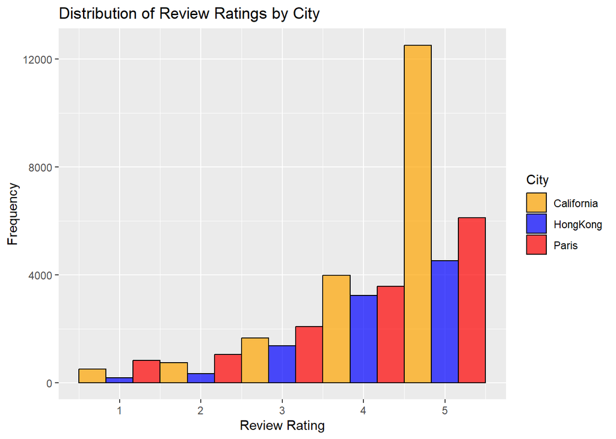

```r
library(ggplot2)
ggplot(data, aes(x = Rating, fill = City)) +
  geom_histogram(binwidth = 1, color = "black", alpha = 0.7, position = "dodge") +
  scale_fill_manual(values = c("HongKong" = "blue", "California" = "orange", "Paris" = "red")) +
  labs(title = "Distribution of Review Ratings by City",
       x = "Review Rating", y = "Frequency")
```

By examining the distribution of ratings for each city, we can observe the spread of ratings and the proportion of reviews receiving each rating. This visualization allows us to compare the distribution of review ratings across different Disneyland park locations, providing insights into the overall satisfaction levels and experiences of visitors in each city. From the graph, it is evident that California has the highest proportion of reviews with a rating of 5 compared to the other cities.

### 3.3 Bar Chart with Ratings using Bing Sentiment

We want to categorize the words in the reviews into positive and negative sentiments using the Bing sentiment lexicon and visualizes the count of positive and negative words in the reviews.

```r
library(tidytext)
data %>%
  select(Review_ID,Review_Text)%>%
  group_by(Review_ID)%>%
  unnest_tokens(output=word,input=Review_Text)%>%
  ungroup()%>%
  inner_join(get_sentiments('bing'))%>%
  group_by(sentiment)%>%
  summarize(n = n())%>%
  mutate(proportion = n/sum(n))
```

```
## # A tibble: 2 × 3
##   sentiment      n proportion
##   <chr>      <int>      <dbl>
## 1 negative  104261      0.284
## 2 positive  262904      0.716
```

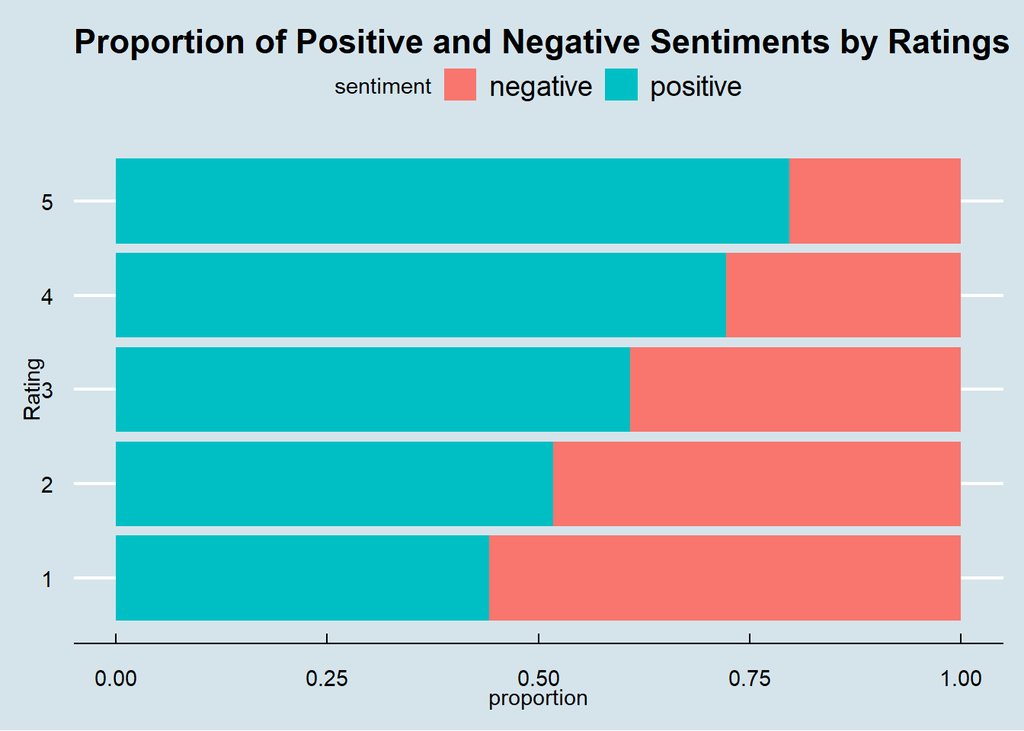

The sentiment analysis reveals a predominance of positive feedback, with 262,904 instances, comprising 71.6% of the total. Conversely, negative sentiments are with 104,261 occurrences, representing about 28.4% of the dataset.

The bar chart represents the proportion of positive and negative sentiments for ratings from 1 to 5. The x-axis displays the proportion, and the y-axis lists the ratings from 1 to 5.

This chart shows that lower ratings have a higher proportion of negative sentiment, while higher ratings show more positive sentiment. This visual underscores the sentiment variation across different rating levels, emphasizing the impact of ratings on sentiment expression.

### 3.4 Bar Chart with Frequencies using NRC Sentiment

```r
data%>%
  group_by(Review_ID)%>%
  unnest_tokens(output = word, input = Review_Text)%>%
  inner_join(nrc)%>%
  group_by(sentiment)%>%
  count()%>%
  arrange(desc(n))
```

```
## # A tibble: 10 × 2
## # Groups:   sentiment [10]
##    sentiment         n
##    <chr>         <int>
##  1 positive     290720
##  2 anticipation 196227
##  3 joy          160638
##  4 trust        144335
##  5 negative     113131
##  6 surprise      84978
##  7 fear          61611
##  8 sadness       49298
##  9 anger         38640
## 10 disgust       26848
```

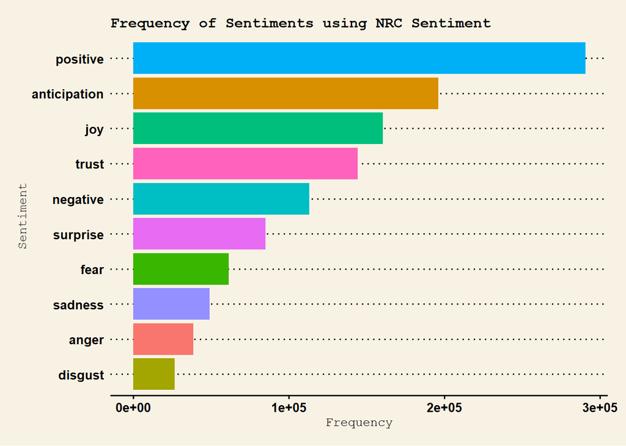

The bar chart indicates the frequency of different sentiments, which x-axis represents the frequency, and the y-axis lists the different sentiments (positive, anticipation, joy, trust, negative, surprise, fear, sadness, anger, disgust).

From the table and the chart indicate that the positive sentiment has the highest frequency, followed by anticipation, joy, and trust, as these sentiments have higher frequencies and may contribute to higher overall ratings. On the other hand, negative sentiment includes negative, fear, sadness, anger and disgust, which disgust has the lowest frequency.

### 3.5 Correlation with Rating using NRC Sentiment

We list different sentiments along with their correlation with rating and significance (p-values). Each row represents a sentiment, and there are three columns: “sentiment,” “correlation with rating,” and “p.”

```
## # A tibble: 10 × 3
##    sentiment    `Correlation with rating` p
##    <chr>                            <dbl> <chr>
##  1 anger                            -0.31 p < 0.05
##  2 anticipation                     -0.07 p < 0.05
##  3 disgust                          -0.34 p < 0.05
##  4 fear                             -0.17 p < 0.05
##  5 joy                              -0.04 p < 0.05
##  6 negative                         -0.27 p < 0.05
##  7 positive                         -0.08 p < 0.05
##  8 sadness                          -0.28 p < 0.05
##  9 surprise                         -0.07 p < 0.05
## 10 trust                            -0.11 p < 0.05
```

The table indicates that each sentiment category shows a negative correlation. As the sentiment category increases, the rating tends to decrease. Like anger, disgust, and sadness have negative correlations with ratings. However, positive, anticipation, and joy show a less negative or near-neutral relationship in reviews and the ratings. In this table, all p-values are less than 0.05, suggesting that the correlations are statistically significant at the 5% level.

### 3.6 Word Cloud Visualizing Review Text

[figure not shown]

```r
library(wordcloud)
wordcloudData =
  data%>%
  group_by(Review_ID)%>%
  unnest_tokens(output=word,input=Review_Text)%>%
  ungroup()%>%
  select(Review_ID,word)%>%
  anti_join(stop_words)%>%
  group_by(word)%>%
  summarize(freq = n())%>%
  arrange(desc(freq))%>%
  ungroup()%>%
  data.frame()

set.seed(617)
wordcloud(words = wordcloudData$word,wordcloudData$freq,scale=c(3,1),max.words = 100,colors=brewer.pal(9,"Spectral"))
```

The purpose of the word cloud visualization is to provide a quick and visually appealing representation of the most frequently occurring words in the review text data, allowing us to easily identify the prominent themes or topics within the reviews, such as park, rides, disney, disneyland and time.

### 3.7 Createing a Corpus and Tokenizing

We would like to analyze document-term matrices using both term frequency and tf-idf weighting methods, providing insights into the importance of terms in the text data based on their frequency and distribution across documents. We first perform several text preprocessing tasks to prepare the text data for analysis. Then we construct a document-term matrix (xdtm) from the corpus, where each row represents a document (review) and each column represents a stemmed term from the text data. Then, we compute tf-idf weights for the terms in the document-term matrix (corpus) using the weightTfIdf() function and visualize the contrast between term frequency and tf-idf weighting methods for the top terms.

```r
#Create a corpus
library(tm)
library(stringr)
longest_review_index = which.max(str_count(string = data$Review_Text,pattern = '\\S+'))

corpus = Corpus(VectorSource(data$Review_Text))
corpus[[longest_review_index]]
```

```
## <<PlainTextDocument>>
## Metadata:  7
## Content:  chars: 20756
```

```r
#Create a dictionary
dict = findFreqTerms(DocumentTermMatrix(Corpus(VectorSource(data$Review_Text))),
                     lowfreq = 0)
dict_corpus = Corpus(VectorSource(dict))
#Stem document
corpus = tm_map(corpus,FUN = stemDocument)
#Create a document term matrix(tokenize)
dtm = DocumentTermMatrix(corpus)
#Remove sparse terms
xdtm = removeSparseTerms(dtm,sparse = 0.95)
#Complete stems
xdtm = as.data.frame(as.matrix(xdtm))
colnames(xdtm) = stemCompletion(x = colnames(xdtm),
                                dictionary = dict_corpus,
                                type='prevalent')
colnames(xdtm) = make.names(colnames(xdtm))
#Browse tokens
sort(colSums(xdtm),decreasing = T)
```

```
##          the          and          was         for.          you          but
##       307693       175480        76391        75782        63191        42187
##         park         were         ride         that          are         with
##        41913        41329        40635        40369        38984        36245
##         have       disney          not        there         time         this
##        35908        33003        32400        29516        28513        28350
##          day          all          get   disneyland          had         they
##        27419        27027        26745        26138        25116        22581
##          our verification          one          can        visit         your
##        21301        19653        19626        16942        16611        16414
##         just         from         wait        would        great        which
##        16382        15642        15017        14534        13787        13775
##         love         when         will        place         more         like
##        13532        13278        13222        13052        12796        12688
##         some          kid       online         food       realli          see
##        12601        12485        12149        12132        11999        11804
##         line         pass         good         even         been         went
##        11656        11330        11093        10915        10877        10855
##         year        queue          out         much        enjoy        about
##        10687        10619        10578        10499        10462        10311
##         show         than         take          lot        peopl         fast
##        10258        10248        10099        10003         9762         9716
##        parad         also         most        other        mania         what
##         9203         9168         9035         8965         8761         8611
##        magic        first         make         long         back         hour
##         8571         8556         8530         8463         8411         8143
##          did         want       around  charactars.        still         then
##         8047         7927         7809         7757         7720         7715
##         over       ticket          got         stay        staff          use
##         7343         7319         7288         7252         7159         7078
##        don.t      attract        could        befor          has         walk
##         7021         6974         6942         6935         6919         6907
##        worth        their        close          too       little        thing
##         6873         6829         6726         6680         6679         6626
##     familiar         need        after         well   everithing        crowd
##         6509         6466         6460         6428         6379         6275
##          fun        small     firework          two       minut.   experiance
##         6270         6231         6209         6199         6194         6176
##        hotel      because        park.     children          old         best
##         6133         6091         5990         5952         5878         5858
```

[output cut: 31 more lines]

```
##         3179         3162         3100         3092         3082         3067
##          buy          eat       though        next.    everyonce        watch
##         3060         3023         3004         2995         2993         2989
##        least        since        young         star         less       wonder
##         2982         2981         2891         2880         2878         2861
##       member         high    somethign        money     especial         save
##         2857         2818         2813         2809         2780         2715
##        can.t          now        drink        those         half       castle
##         2709         2705         2673         2661         2645         2616
##          age        light     although    managable       anothe          pay
##         2582         2578         2575         2564         2552         2546
##         full       pirate       return         such         once         give
##         2543         2539         2517         2495         2473         2462
##        until         part      without        clean      smaller
##         2459         2405         2355         2350         2319
```

From the table, the top 100 frequent terms in the dataset highlight Disneyland experiences, emphasizing activities, such as (“park”, “ride”), positive sentiments (“great”, “love”), facilities (“staff”, “food”), and attractions (“parade”, “show”). Visitors express enjoyment and evaluate experiences, reflecting a diverse range of opinions and experiences at Disneyland.

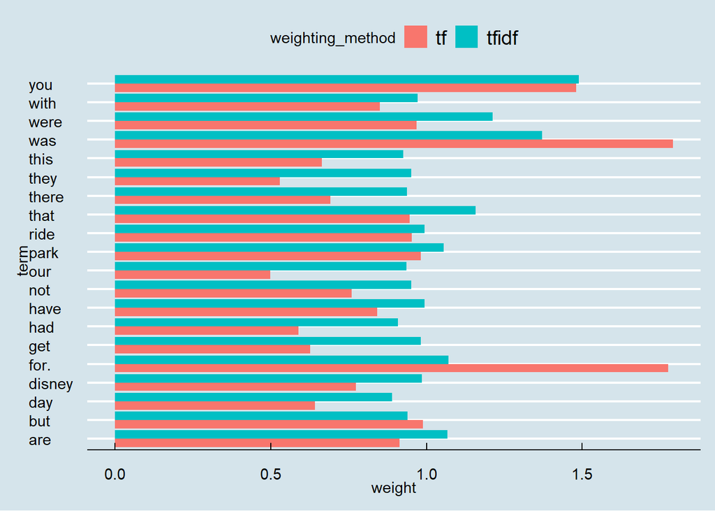

```r
#Document Term Matrix-tfidf:term frequency inverse document frequency weighting
dtm_tfidf = DocumentTermMatrix(x=corpus,
                               control = list(weighting=function(x) weightTfIdf(x,normalize=F)))
xdtm_tfidf = removeSparseTerms(dtm_tfidf,sparse = 0.95)
xdtm_tfidf = as.data.frame(as.matrix(xdtm_tfidf))
colnames(xdtm_tfidf) = stemCompletion(x = colnames(xdtm_tfidf),
                                      dictionary = dict_corpus,
                                      type='prevalent')
colnames(xdtm_tfidf) = make.names(colnames(xdtm_tfidf))

#Bar chart for Top 20 terms contrasts between
#weights of term frequency and term frequency inverse document frequency weighting
library(tidyr); library(dplyr); library(ggplot2); library(ggthemes)
data.frame(term = colnames(xdtm),tf = colMeans(xdtm), tfidf = colMeans(xdtm_tfidf))%>%
  arrange(desc(tf))%>%
  top_n(20)%>%
  gather(key=weighting_method,value=weight,2:3)%>%
  ggplot(aes(x=term,y=weight,fill=weighting_method))+
  geom_col(position='dodge')+
  coord_flip()+
  theme_economist()
```

The graph illustrates the comparison between term frequency (TF) and term frequency-inverse document frequency (TF-IDF) weights for select terms. TF-IDF weighting assigns higher importance to terms based on their frequency within documents and across the corpus. Terms like “park”, “day”, “disney” and “ride” have higher TF-IDF weights compared to TF, indicating their significance in representing document content across the corpus. Conversely, terms like “was” and “for” have higher TF weights than TF-IDF, suggesting their importance within individual documents but less significance across the corpus.

### 3.8 Analyzing Bigrams and N-grams

Now we’d like to extend our analysis to consider pairs of words (bigrams) and more generally N-grams. Moreover, if we can determine how often word X is followed by word Y, we can build a model by exploiting the relationships between them.

```r
library(dplyr)
library(tidyr)
library(tidytext)
data_bigrams <- data %>%
  unnest_tokens(bigram, Review_Text, token = "ngrams", n=2)

bigrams_separated <- data_bigrams %>%
  separate(bigram, c('word1', 'word2'), sep=' ')

bigrams_filtered <- bigrams_separated %>%
  filter(!word1 %in% stop_words$word) %>%
  filter(!word2 %in% stop_words$word)

bigram_counts <- bigrams_filtered %>%
  count(word1, word2, sort = TRUE) %>%
  arrange(desc(n))
```

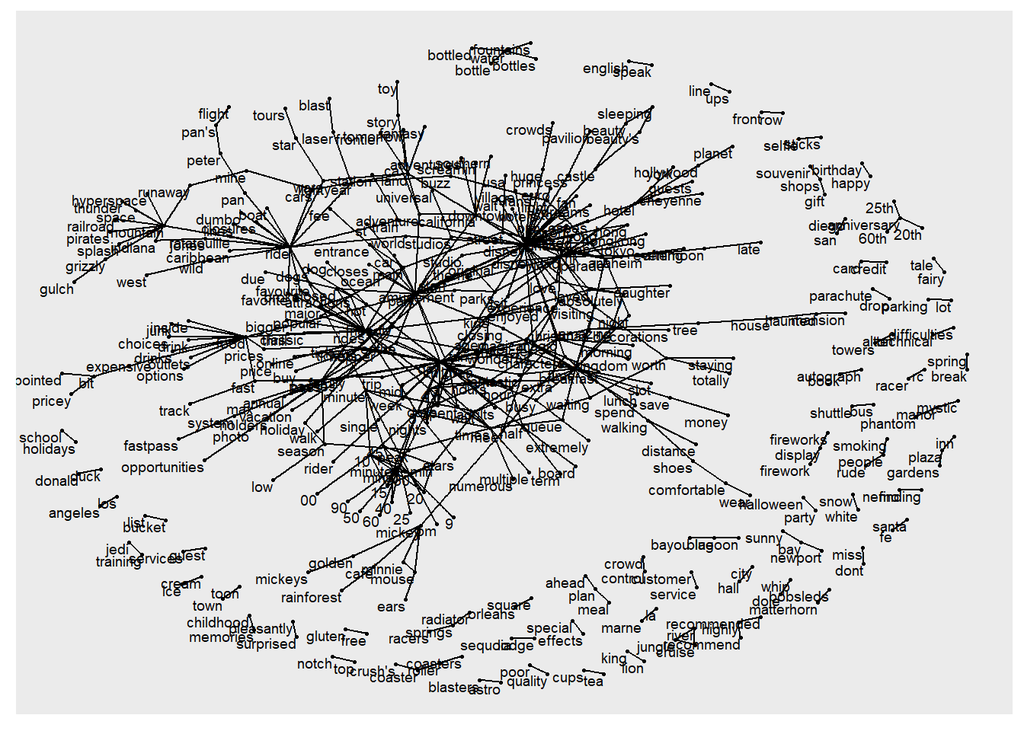

```r
#Visualizing Word Relationships with Graphs
library(igraph)
bigram_graph <- bigram_counts %>%
  # We limit to just pairs with alteast 100+ observations since the graph can become very clusters. Feel free to experiment.
  filter(n > 100) %>%
  graph_from_data_frame()

#convert igraph to ggraph for plotting
library(ggraph)
set.seed(617)

ggraph(bigram_graph, layout = 'fr')+
  geom_edge_link(size = 0.01,arrow_size = 0.05)+
  geom_node_point(size = 0.5) +
  geom_node_text(aes(label = name), vjust =1, hjust =1,size = 2.5)
```

This visualization provides a graphical representation of the relationships between bigrams in the text data, allowing for visual exploration of common word pairs and potential patterns or clusters within the data.

### 3.9 Word Embeddings on PMI

We further conduct analysis that take into account the context surrounding particular words (targets). By organizing words within each review into nested structures, the code readies the data for subsequent processing, including the identification of neighboring words within a specified window size.

Then our analysis aims to capture the semantic relationships between words in the reviews and visualize them in a lower-dimensional space. It enables tasks such as finding similar words, identifying word associations, and exploring the semantic structure of the review vocabulary.

```r
#Construct word embeddings based on PMI
library(slider)
library(tidytext)
library(tidyr)
slide_windows <- function(tbl, window_size) {
  skipgrams <- slider::slide(
    tbl, ~.x, .after = window_size - 1, .step = 1, .complete = TRUE
  )
  safe_mutate <- safely(mutate)
  out <- map2(skipgrams, 1:length(skipgrams), ~ safe_mutate(.x, window_id = .y))
  out %>%
    transpose() %>%
    pluck("result") %>%
    compact() %>%
    bind_rows()
}
#start from the top  with our tokenized into single words, with stops removed.
tidyreviews <- data %>%
  select(Review_ID,Review_Text)%>%
  group_by(Review_ID)%>%
  unnest_tokens(output=word,input=Review_Text)%>%
  anti_join(stop_words)%>%
  ungroup()

#Now that we have “cleaned” our dataset, we need to go backwards and reconstruct the reviews (minus the stop words).
# This is necessary so we can see the surrounding words to our targets in the window.
nested_words <- tidyreviews %>%
  nest(words = c(word))

head(nested_words)
```

```
## # A tibble: 6 × 2
##   Review_ID words
##       <int> <list>
## 1 670772142 <tibble [24 × 1]>
## 2 670682799 <tibble [70 × 1]>
## 3 670623270 <tibble [58 × 1]>
## 4 670607911 <tibble [31 × 1]>
## 5 670607296 <tibble [12 × 1]>
## 6 670591897 <tibble [63 × 1]>
```

```r
#Construct word embeddings based on PMI
library(furrr)
library(tictoc)
library(irlba)
library(widyr)
tic()
plan(multisession)  # invoke parallel processing

tidy_pmi <- nested_words %>%
  mutate(words = future_map(words, slide_windows, 4)) %>%
  unnest(words) %>%
  unite(window_id, Review_ID, window_id) %>%
  pairwise_pmi(word, window_id)
toc(log=TRUE)
```

```
## 2316.75 sec elapsed
```

```r
plan(sequential)
```

We further aim to analyze word associations in customer reviews. We employ a Singular Value Decomposition (SVD) approach to create word vectors and then identifies nearest neighbors for specific words of interest, such as “park,” “amazing,” “disappointed,” “fee,” “negative,” and “bad”, aiding in addressing our research questions. Additionally, we visualize principal components to discern underlying patterns in word correlations.

```r
# "park"
tidy_word_vectors %>%
  nearest_neighbors("park")
```

```
## # A tibble: 63,433 × 2
##    item1       value
##    <chr>       <dbl>
##  1 park       0.693
##  2 theme      0.133
##  3 clean      0.0737
##  4 day        0.0714
##  5 disneyland 0.0713
##  6 parks      0.0603
##  7 ride       0.0549
##  8 disney     0.0477
##  9 children   0.0471
## 10 tickets    0.0462
## # ℹ 63,423 more rows
```

```r
#'amazing' reviews
tidy_word_vectors %>%
  nearest_neighbors("amazing")
```

```
## # A tibble: 63,433 × 2
##    item1       value
##    <chr>       <dbl>
##  1 amazing    0.0748
##  2 experience 0.0642
##  3 fireworks  0.0514
##  4 magical    0.0416
##  5 loved      0.0350
##  6 parades    0.0342
##  7 worth      0.0315
##  8 parade     0.0304
##  9 fantastic  0.0291
## 10 night      0.0266
## # ℹ 63,423 more rows
```

```r
#"disappointed"
tidy_word_vectors %>%
  nearest_neighbors("disappointed")
```

```
## # A tibble: 63,433 × 2
##    item1         value
##    <chr>         <dbl>
##  1 disappointed 0.0241
##  2 bit          0.0208
##  3 left         0.0186
##  4 closed       0.0185
##  5 characters   0.0182
##  6 florida      0.0179
##  7 paris        0.0154
##  8 due          0.0129
##  9 feel         0.0116
## 10 trip         0.0110
## # ℹ 63,423 more rows
```

```r
#'fee'
tidy_word_vectors %>%
  nearest_neighbors("fee")
```

```
## # A tibble: 63,433 × 2
##    item1      value
##    <chr>      <dbl>
##  1 cost      0.0208
##  2 price     0.0207
##  3 worth     0.0206
##  4 fee       0.0185
##  5 entrance  0.0159
##  6 pay       0.0150
##  7 hkd       0.0150
##  8 paid      0.0140
##  9 parking   0.0131
## 10 admission 0.0129
## # ℹ 63,423 more rows
```

```r
#'negative'
tidy_word_vectors %>%
  nearest_neighbors("negative")
```

```
## # A tibble: 63,433 × 2
##    item1        value
##    <chr>        <dbl>
##  1 reviews     0.0339
##  2 read        0.0298
##  3 review      0.0282
##  4 negative    0.0220
##  5 people      0.0209
##  6 reading     0.0161
##  7 trip        0.0149
##  8 park        0.0120
##  9 tips        0.0115
## 10 tripadvisor 0.0113
## # ℹ 63,423 more rows
```

```r
#'bad'
tidy_word_vectors %>%
  nearest_neighbors("bad")
```

```
## # A tibble: 63,433 × 2
##    item1       value
##    <chr>       <dbl>
##  1 experience 0.0578
##  2 bad        0.0454
##  3 queues     0.0273
##  4 kids       0.0225
##  5 read       0.0223
##  6 reviews    0.0217
##  7 lot        0.0212
##  8 expected   0.0197
##  9 busy       0.0179
## 10 left       0.0179
## # ℹ 63,423 more rows
```

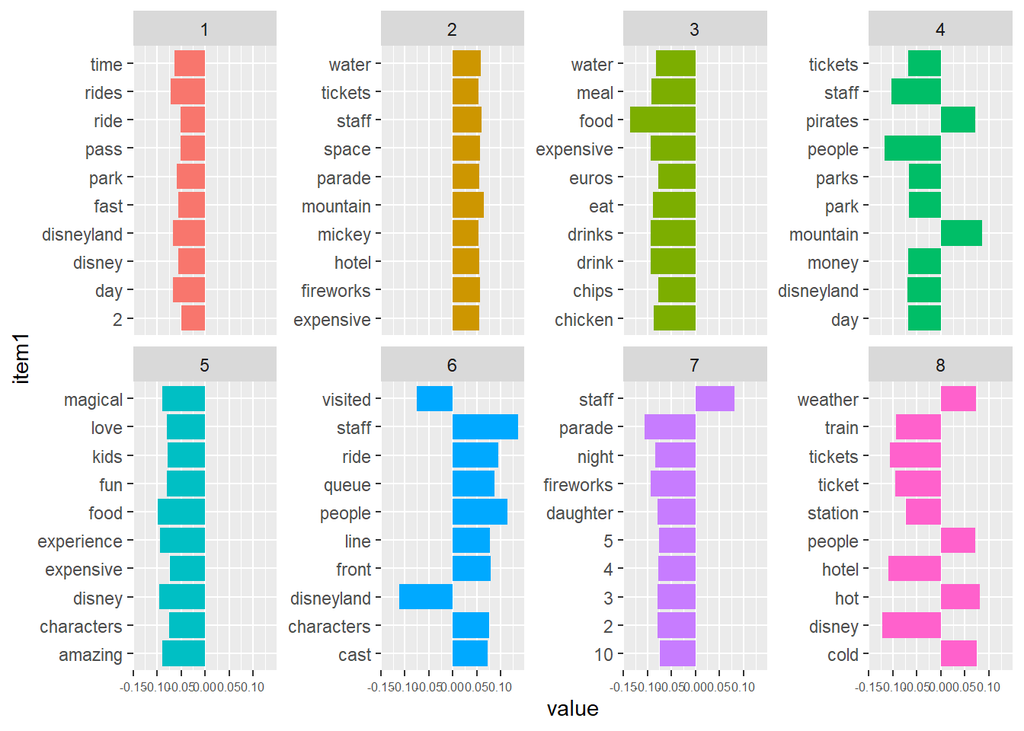

```r
#Principal components
library(ggplot2)
tidy_word_vectors %>%
  filter(dimension <= 8) %>%
  group_by(dimension) %>%
  top_n(10, abs(value)) %>%
  ungroup %>%
  ggplot(aes(value, item1, fill = as.factor(dimension))) +
  geom_col(show.legend = FALSE) +
  facet_wrap(~dimension, scales = "free_y", ncol = 4)+
  theme(axis.text.x = element_text(size = 6))
```

The tables allow us to examine the correlations between specific words and identify their nearest neighbors. For example, the words most strongly associated with “disappointed” are “Bit,” “left,” “closed,” and “characters”. Other notable terms include “Florida,” “Paris,” “due,” “feel,” and “trip.” These associations suggest potential reasons or contexts contributing to customers feeling disappointed, such as specific experiences, locations, or circumstances mentioned in the reviews.

In short, using the PMI method to plot the graph allow us to visualize these associations and identify thematic clusters within the dataset. And we can gain deeper insights into the varying aspects of customer experiences, enabling Disney to address concerns, capitalize on strengths, and enhance overall visitor satisfaction.

# **Part 4. Time series Analysis**

In our time series analysis, we aimed to understand and predict two critical aspects of Disneyland park operations: customer ratings and monthly visitor numbers through time series forecasting. By leveraging techniques such as seasonal naive and ARIMA modeling, we sought to uncover underlying patterns and seasonal trends in these datasets, which enable strategic planning and decision-making for park management and marketing teams.

### 4.1 Preparing data on Rating

```r
#ts on rating
#ts
library(tseries)
library(forecast)
```

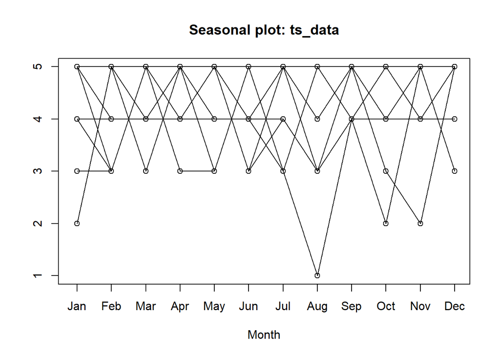

```r
#install.packages('lubridate')
library(lubridate)
data$Date <- as.Date(paste(data$Year, data$Month, "01", sep = "-"))

ts_data <- ts(data$Rating, start = c(2010, 03),end=c(2019,05),frequency = 12)
seasonplot(ts_data)
```

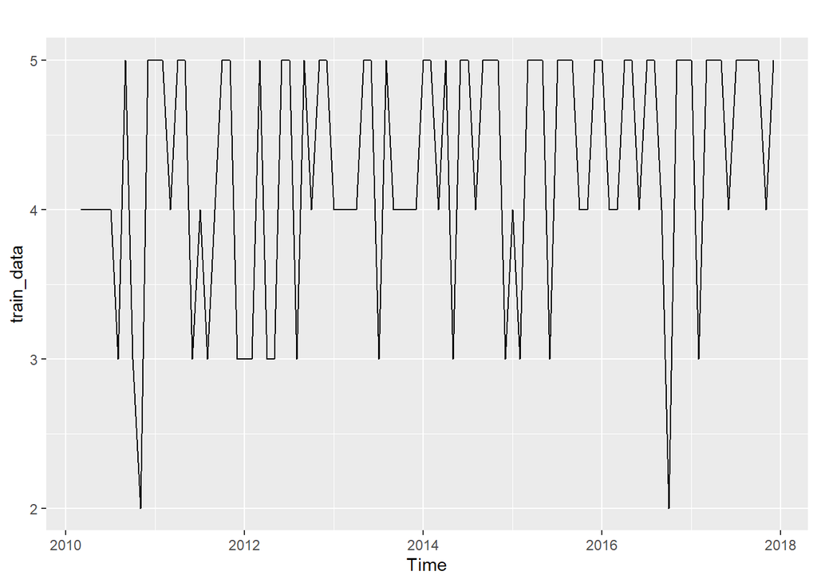

```r
train_data=window(ts_data,end=c(2017, 12))
test_data=window(ts_data,start=c(2018,01))

# check for autocorrelations
autoplot(train_data)
```

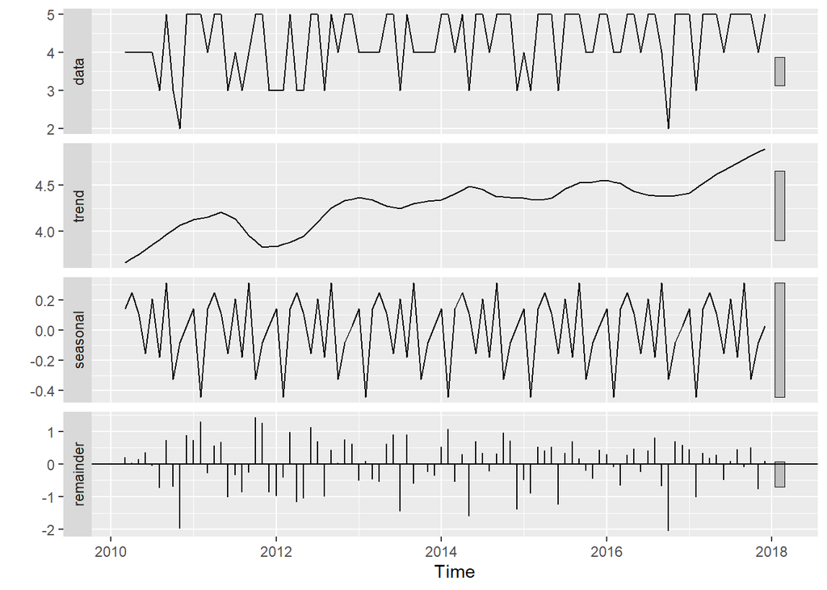

```r
#Graph to check trend, seasonality,and reminders
train_data%>%
  stl(s.window = 'periodic')%>%
  autoplot()
```

The graph displays distinct trends and seasonal shifts in people’s ratings. Although the pronounced cycles in the train data might initially suggest non-stationarity, their periodic nature indicates that a seasonal naive model could be a suitable approach for forecasting.

### 4.2 Seasonal Naive Model

```r
seasonal_naive_model = snaive(train_data,h=17)
seasonal_naive_model
```

```
##          Point Forecast     Lo 80    Hi 80      Lo 95    Hi 95
## Jan 2018              5 3.3988422 6.601158  2.5512404 7.448760
## Feb 2018              3 1.3988422 4.601158  0.5512404 5.448760
## Mar 2018              5 3.3988422 6.601158  2.5512404 7.448760
## Apr 2018              5 3.3988422 6.601158  2.5512404 7.448760
## May 2018              5 3.3988422 6.601158  2.5512404 7.448760
## Jun 2018              4 2.3988422 5.601158  1.5512404 6.448760
## Jul 2018              5 3.3988422 6.601158  2.5512404 7.448760
## Aug 2018              5 3.3988422 6.601158  2.5512404 7.448760
## Sep 2018              5 3.3988422 6.601158  2.5512404 7.448760
## Oct 2018              5 3.3988422 6.601158  2.5512404 7.448760
## Nov 2018              4 2.3988422 5.601158  1.5512404 6.448760
## Dec 2018              5 3.3988422 6.601158  2.5512404 7.448760
## Jan 2019              5 2.7356209 7.264379  1.5369310 8.463069
## Feb 2019              3 0.7356209 5.264379 -0.4630690 6.463069
## Mar 2019              5 2.7356209 7.264379  1.5369310 8.463069
## Apr 2019              5 2.7356209 7.264379  1.5369310 8.463069
## May 2019              5 2.7356209 7.264379  1.5369310 8.463069
```

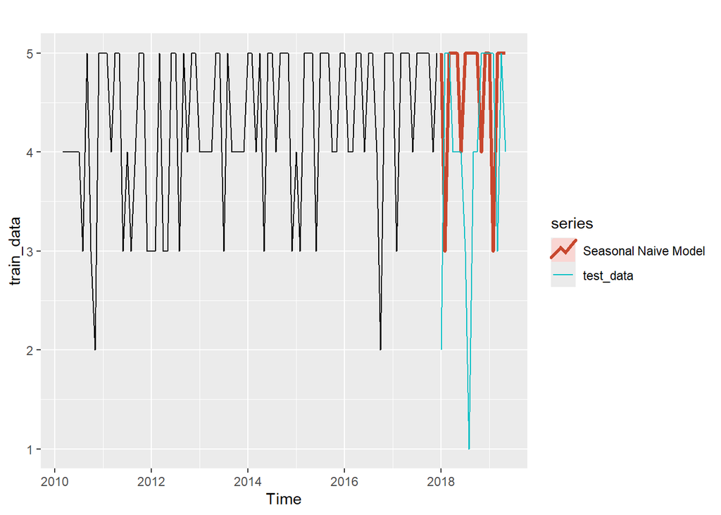

```r
library(forecast) # Set of forecasting functions

#Plot the forecast to see results
autoplot(train_data)+
  autolayer(seasonal_naive_model,PI=F,size=1.1,series='Seasonal Naive Model')+
  autolayer(test_data)
```

```r
#We checked the accuracy of seasonal_naive_model
seasonal_naive_model$mean
```

```
##      Jan Feb Mar Apr May Jun Jul Aug Sep Oct Nov Dec
## 2018   5   3   5   5   5   4   5   5   5   5   4   5
## 2019   5   3   5   5   5
```

```r
accuracy(seasonal_naive_model, ts_data)
```

```
##                       ME    RMSE       MAE        MPE     MAPE     MASE
## Training set  0.09756098 1.24939 0.9756098  -2.682927 24.75610 1.000000
## Test set     -0.64705882 1.66274 1.2352941 -41.666667 53.43137 1.266176
##                     ACF1 Theil's U
## Training set -0.05337236        NA
## Test set     -0.04884609 0.6075421
```

From the printed results for the mean of forecasts, we can see that Feburary has a the lowest average rating among its counterparts. The forecast ratings in June and Novemeber are both 4 out of 5, which are also the valley in all-year rating.

In the accuracy assessment, the test data yielded an RMSE (Root Mean Square Error) of 1.66, while the train data recorded an RMSE of 1.24. These figures are justifiable given that Disneyland’s consistent service quality minimizes random fluctuations in customer experience ratings across different seasons. Typically, the most significant variables impacting customer satisfaction would be queuing times as discussed in the text mining part, which occurs cyclinically.

To double check our seasonal naive model make good prediction, we need to examine if the residuals are white noise.

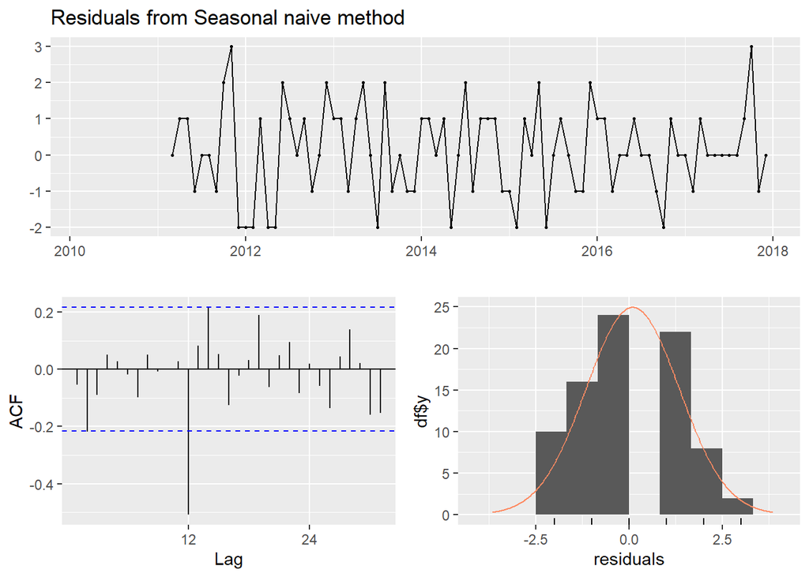

```
##
##  Ljung-Box test
##
## data:  Residuals from Seasonal naive method
## Q* = 43.488, df = 19, p-value = 0.001111
##
## Model df: 0.   Total lags used: 19
```

```r
checkresiduals(seasonal_naive_model)
```

```r
residuals_data <- residuals(seasonal_naive_model)
```

The small p-value (0.0011) from the Ljung-Box test provides strong evidence of autocorrelation in the residuals across the first 19 lags. Furthermore, the autocorrelation plots confirm that the residuals from the seasonal naive model do not constitute white noise.

Consequently, we must consider an alternative modeling approach to address the heteroskedasticity within the residuals. An ARIMA model is well-suited for eliminating autocorrelations and seasonality, making it the preferred choice in this scenario.

### 4.3 ARIMA Model

```r
arima_model <- Arima(train_data, order=c(0,1,1), seasonal=list(order=c(1,1,1), period=12))

# Print the summary of the ARIMA model
summary(arima_model)
```

```
## Series: train_data
## ARIMA(0,1,1)(1,1,1)[12]
##
## Coefficients:
##          ma1     sar1     sma1
##       -1.000  -0.2656  -0.7248
## s.e.   0.049   0.1620   0.2183
##
## sigma^2 = 0.7737:  log likelihood = -113.15
## AIC=234.29   AICc=234.82   BIC=243.87
##
## Training set error measures:
##                       ME      RMSE      MAE       MPE     MAPE      MASE
## Training set -0.02431015 0.8012351 0.606221 -4.192807 15.89686 0.6213765
##                     ACF1
## Training set -0.06019714
```

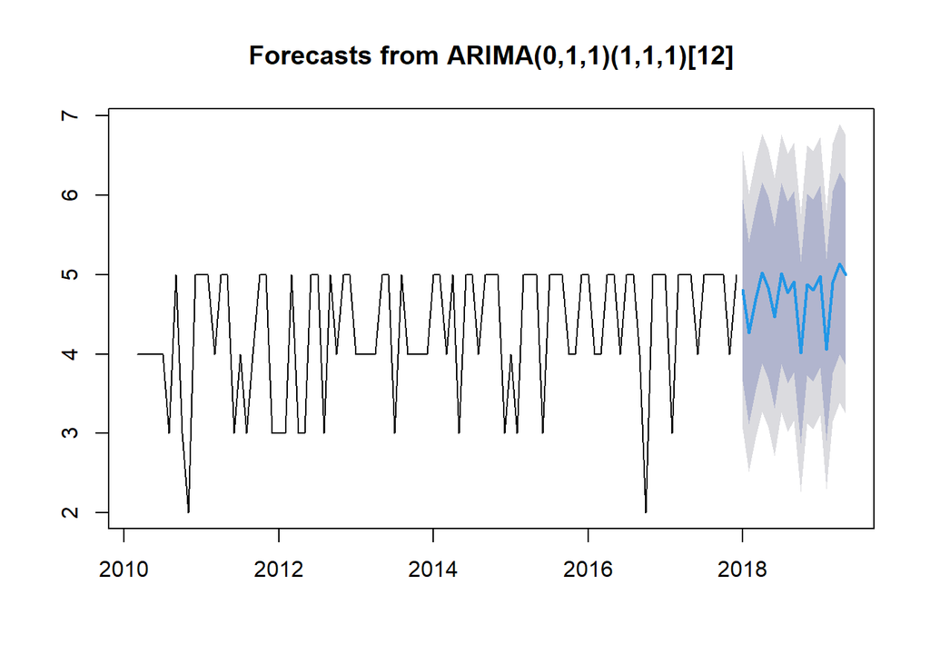

```r
# we can also forecast using this model
forecasted_values <- forecast(arima_model, h=length(test_data))
plot(forecasted_values)
```

Based on our plots, we can see that our points of forecast greatly captures seasonality and trend. To better assess the accuracy of our forecast mode, we use ADF test to see if the residuals are independently and identically distributed, i.i.d.

```r
arima_residuals <-residuals(arima_model)
# Check the residuals of the ARIMA model
adf_test_arima <- adf.test(arima_residuals, alternative = "stationary")
print(adf_test_arima)
```

```
##
##  Augmented Dickey-Fuller Test
##
## data:  arima_residuals
## Dickey-Fuller = -5.0475, Lag order = 4, p-value = 0.01
## alternative hypothesis: stationary
```

```r
# If the residuals from ARIMA model are stationary, we can then check for white noise
Box.test(arima_residuals, type = "Ljung-Box")
```

```
##
##  Box-Ljung test
##
## data:  arima_residuals
## X-squared = 0.35162, df = 1, p-value = 0.5532
```

Based on our results in Augmented Dickey-Fuller test, we can see that a p-value of 0.01 have made us succeed to reject the null hypothesis and conclude that the residuals from arima model are stationary. In addition, Box-Ljung test shows that our residuals are indeed white noise. We can conclude that our ARIMA model with a seasonal difference of 12 month make great forecast for ratings.

### 4.4 Preparing data on population

```r
#ts on population
library(dplyr)
library(forecast)
library(lubridate)

#This code aggregates the data by year and month, calculates the count of records for each combination of year and month,and creates a new column "Year_Month" to represent this combination. Finally, it arranges the resulting dataframe in chronological order.
monthly_counts <- data %>%
  group_by(Year, Month) %>%
  summarise(Count = n()) %>%
  mutate(Year_Month = paste(Year, Month, sep = "-")) %>%
  select(Year_Month, Count) %>%
  arrange(Year_Month)
monthly_counts
```

```
## # A tibble: 112 × 3
## # Groups:   Year [11]
##     Year Year_Month Count
##    <int> <chr>      <int>
##  1  2010 2010-10       21
##  2  2010 2010-11       27
##  3  2010 2010-12       56
##  4  2010 2010-3         2
##  5  2010 2010-4         1
##  6  2010 2010-5         4
##  7  2010 2010-6         8
##  8  2010 2010-7         7
##  9  2010 2010-8         7
## 10  2010 2010-9        10
## # ℹ 102 more rows
```

```r
#Setting Data as Time Series for later calculation
ts_data <- ts(monthly_counts$Count, start = c(2010, 03), end = c(2019, 05), frequency = 12)

#It converts the "Count" column from the "monthly_counts" dataframe into a time series object, specifying the start and end dates as well as the frequency of observations per year.
```

It then splits this time series dataset into training and testing sets. The training set includes data up to April 2018, while the testing set includes data from May 2018 to May 2019.

### 4.5 SARIMA Model

```r
train_data <- window(ts_data, end = c(2018, 04))
test_data <- window(ts_data, start = c(2018, 05), end = c(2019, 05))

# Apply Box-Cox transformation based on the training dataset to find the optimal lambda parameter. By using this, can ensure the final data variance is stabilized.
train_data_boxcox <- BoxCox(train_data, lambda = BoxCox.lambda(train_data))
# Employ the diff function to compute the differences between consecutive elements in the train dataset. Setting lag equal to 4 means that the difference between each observation and the observation four months prior in the series will be calculated. This differencing technique help eliminating the trends or seasonal patterns within the data, to achieve more stationary and appropriate data for prediction.
train_data_diff <- diff(train_data_boxcox, lag = 4)

#Determine the number of differences needed from the diff function to eliminate the trend and seasonal effect.
d <- ndiffs(train_data_diff)
```

Even after applying the BoxCox transformation, the data exhibited a pronounced trend and seasonality. Consequently, sarima model will be employed to mitigate this issue. The seasonal parameter set to be TRUE ensures the function accounts for potential seasonal patterns within the data. The parameters d and D specify the order of non-seasonal and seasonal differencing, respectively, required to achieve stationarity in the data. These values were previously determined using the ndiffs() function. Setting D = 1 signifies that seasonal differencing of order 1 will be performed. The function automatically identifies the optimal ARIMA model based on the AIC and returns the fitted model.

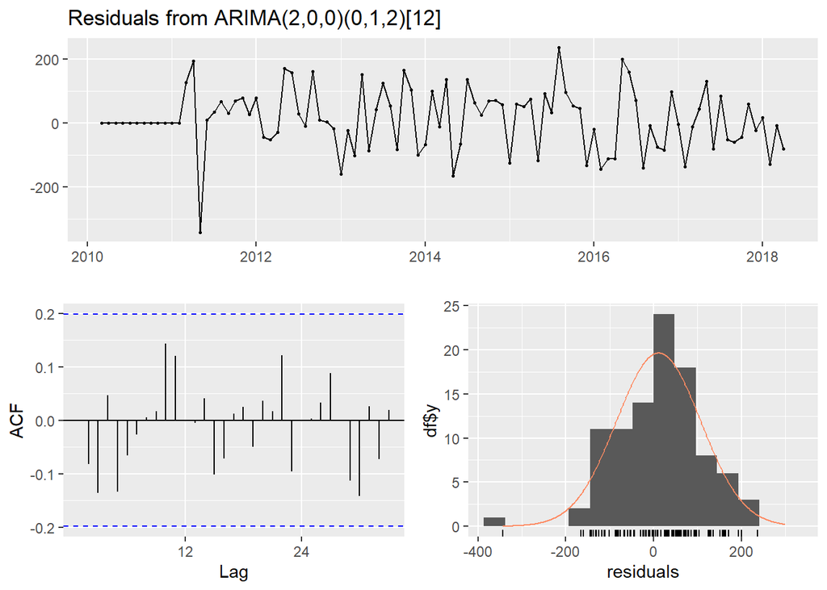

```
##
##  Ljung-Box test
##
## data:  Residuals from ARIMA(2,0,0)(0,1,2)[12]
## Q* = 11.771, df = 16, p-value = 0.7596
##
## Model df: 4.   Total lags used: 20
```

```r
model <- auto.arima(train_data_boxcox, seasonal = TRUE, d = d, D = 1)

# This will be used to check the residuals of the model. From the ACF graph and p-value, the residual of this model can be certained as white noise.
checkresiduals(model)
```

### 4.6 Forecasting

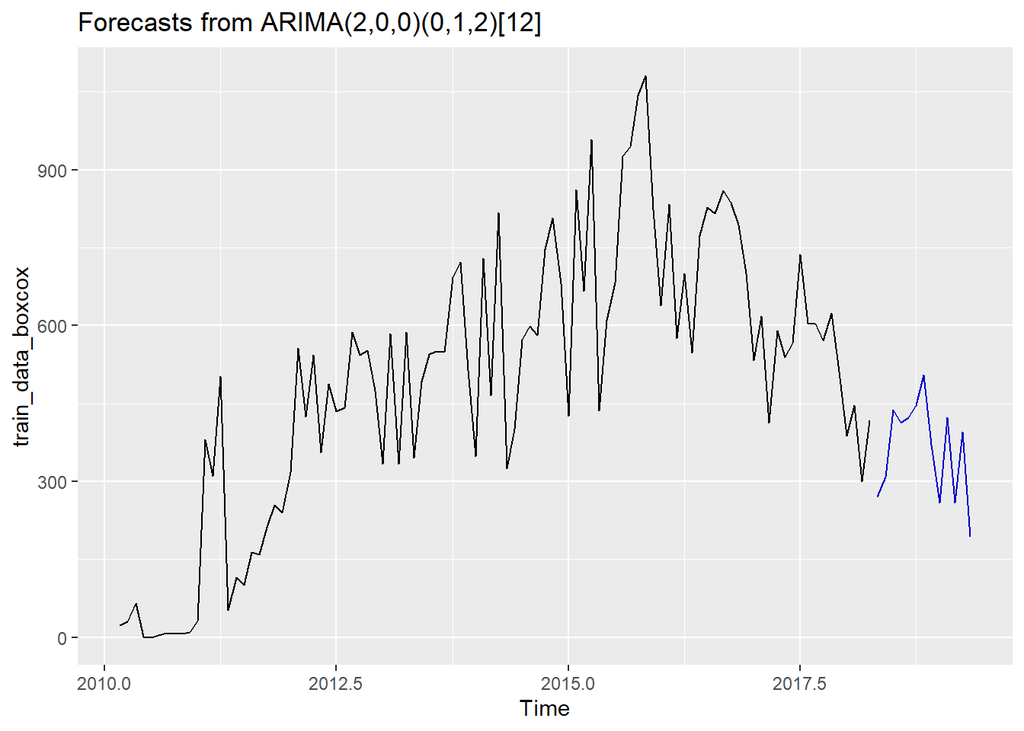

```r
# Using forecast to predict the value about the test data.
forecast_values <- forecast(model, h = length(test_data))

# Invert Box-Cox transformation to get forecasts in original scale
forecast_values_inv <- InvBoxCox(forecast_values$mean, lambda = BoxCox.lambda(train_data))

# Plot forecasts
autoplot(forecast_values, PI = FALSE)
```

```r
# Evaluate accuracy. The result shows that RMSE is about 82 which means the final result is similar to the test value and ME is about -2 which indicates a relatively small average bias in the forecasts.
accuracy(forecast_values_inv, ts_data)
```

```
##                 ME     RMSE      MAE       MPE     MAPE      ACF1 Theil's U
## Test set -2.158478 82.00233 66.90711 -589.7996 608.9096 0.3703108  1.134092
```

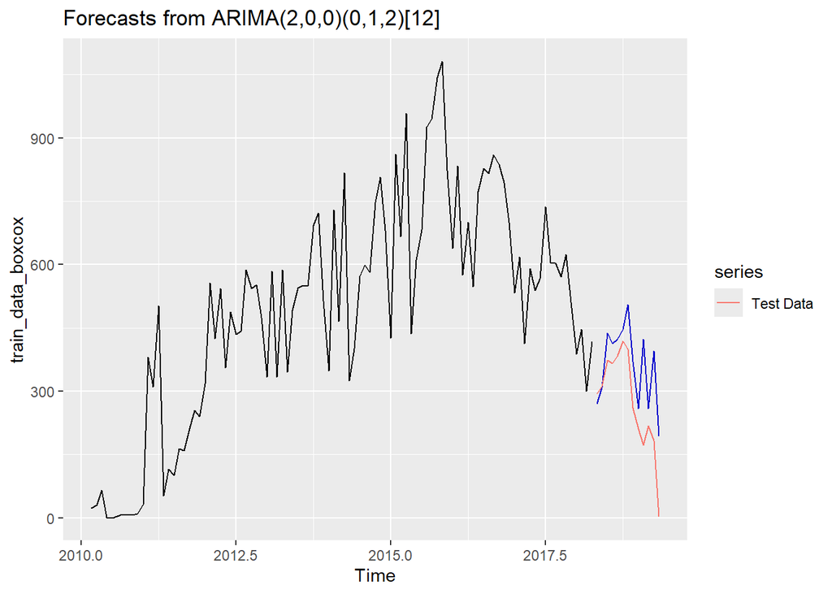

```r
# Plot forecasts with test data.
autoplot(forecast_values, PI = FALSE) +
  autolayer(test_data, series = "Test Data")
```

# **Part 5: Summary**

Our project encompasses a comprehensive analysis of customer sentiment and visitor trends at Disneyland. Through techniques like sentiment analysis, word embeddings, and time series modeling, we gained valuable insights into customer perceptions, seasonal variations, and forecasting future visitor numbers.

Initially, we utilized sentiment analysis and word embeddings to understand the semantic context of customer reviews, and identify thematic clusters and sentiment trends. The sentiment analysis revealed that customers predominantly express positive sentiments in their reviews, indicating overall satisfaction with their Disneyland experiences. On the other hand, negative sentiments correlate with lower ratings, highlighting areas for improvement to enhance customer satisfaction further. Additionally, the analysis of frequent terms and word embeddings illustrate key themes and associations within the reviews. These findings offer valuable information for understanding visitor experiences to guide strategic decisions and enhance customer satisfaction by improving overall park offerings.